# Module 10 Weekly Report

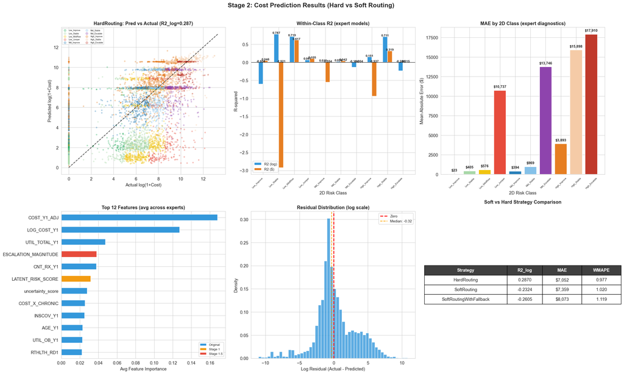

```python
# VISUALIZATION: Stage 2 Results (Hard vs Soft Routing)

fig, axes = plt.subplots(2, 3, figsize=(22, 13))
fig.suptitle('Stage 2: Cost Prediction Results (Hard vs Soft Routing)', fontsize=16, fontweight='bold', y=1.01)

trans_colors = {
    0: '#27ae60', 1: '#a8d8a8', 2: '#f1c40f', 3: '#e74c3c',
    4: '#2980b9', 5: '#85c1e9', 6: '#8e44ad',
    7: '#e67e22', 8: '#f5cba7', 9: '#c0392b',
}

# Panel 1: Pred vs Actual (selected strategy, log scale)
ax1 = axes[0, 0]
for t, tn in tier_names.items():
    m = df_test['RISK_TIER'] == t
    if m.sum() > 0:
        ax1.scatter(y_test_log[m], y_pred_test_log[m], c=trans_colors[t], alpha=0.28, s=8, label=tn)
lim = [0, max(y_test_log.max(), y_pred_test_log.max()) + 0.3]
ax1.plot(lim, lim, 'k--', lw=1.5, alpha=0.7)
ax1.set_xlabel('Actual log(1+Cost)', fontsize=11)
ax1.set_ylabel('Predicted log(1+Cost)', fontsize=11)
r2_overall = r2_score(y_test_log, y_pred_test_log)
ax1.set_title(f'{best_strategy_name}: Pred vs Actual (R2_log={r2_overall:.3f})', fontsize=12, fontweight='bold')
ax1.legend(fontsize=5, markerscale=2, ncol=2)

# Panel 2: Within-tier R2 diagnostics from class experts
ax2 = axes[0, 1]
tier_list = [tn for tn in tier_names.values() if tn in tier_models]
r2_logs = [tier_models[tn]['r2_log'] for tn in tier_list]
r2_dollars = [tier_models[tn]['r2_dollar'] for tn in tier_list]
x = np.arange(len(tier_list))
bars1 = ax2.bar(x - 0.15, r2_logs, 0.3, label='R2 (log)', color='#3498db', edgecolor='white')
bars2 = ax2.bar(x + 0.15, r2_dollars, 0.3, label='R2 ($)', color='#e67e22', edgecolor='white')
for b, v in zip(bars1, r2_logs):
    ax2.text(b.get_x() + b.get_width()/2, max(v, 0) + 0.01, f'{v:.3f}', ha='center', fontsize=8, fontweight='bold')
for b, v in zip(bars2, r2_dollars):
    ax2.text(b.get_x() + b.get_width()/2, max(v, 0) + 0.01, f'{v:.3f}', ha='center', fontsize=8, fontweight='bold')
ax2.axhline(y=0, color='black', lw=0.8)
ax2.set_xticks(x)
ax2.set_xticklabels(tier_list, fontsize=6, rotation=45, ha='right')
ax2.set_xlabel('2D Risk Class', fontsize=11)
ax2.set_ylabel('R-squared', fontsize=11)
ax2.set_title('Within-Class R2 (expert models)', fontsize=12, fontweight='bold')
ax2.legend(fontsize=9)

# Panel 3: MAE by tier (expert diagnostics)
ax3 = axes[0, 2]
maes = [tier_models[tn]['mae'] for tn in tier_list]
tier_color_list = [trans_colors[k] for k, v in tier_names.items() if v in tier_models]
bars = ax3.bar(tier_list, maes, color=tier_color_list, edgecolor='white')
for b, v in zip(bars, maes):
    ax3.text(b.get_x() + b.get_width()/2, v + max(maes)*0.02, f'${v:,.0f}', ha='center', fontsize=9, fontweight='bold')
ax3.set_xlabel('2D Risk Class', fontsize=11)
ax3.set_ylabel('Mean Absolute Error ($)', fontsize=11)
ax3.set_title('MAE by 2D Class (expert diagnostics)', fontsize=12, fontweight='bold')
ax3.tick_params(axis='x', rotation=45, labelsize=6)

# Panel 4: Feature importance averaged across experts
ax4 = axes[1, 0]
all_imp = pd.DataFrame({tn: info['importance'] for tn, info in tier_models.items()})
avg_imp = all_imp.mean(axis=1).sort_values(ascending=False).head(12)
feat_colors = ['#e74c3c' if f in STAGE1_5_FEATS else '#f39c12' if f == 'LATENT_RISK_SCORE' else '#3498db' for f in avg_imp.index]
avg_imp.plot(kind='barh', ax=ax4, color=feat_colors)
ax4.set_xlabel('Avg Feature Importance', fontsize=11)
ax4.set_title('Top 12 Features (avg across experts)', fontsize=12, fontweight='bold')
ax4.invert_yaxis()
from matplotlib.patches import Patch
ax4.legend(handles=[Patch(fc='#3498db', label='Original'), Patch(fc='#f39c12', label='Stage 1'), Patch(fc='#e74c3c', label='Stage 1.5')], fontsize=8)

# Panel 5: Residual distribution (selected strategy)
ax5 = axes[1, 1]
resids_log = y_test_log - y_pred_test_log
ax5.hist(resids_log, bins=50, color='#3498db', edgecolor='white', alpha=0.8, density=True)
ax5.axvline(x=0, color='red', ls='--', lw=2, label='Zero')
ax5.axvline(x=np.median(resids_log), color='orange', ls='--', lw=1.5, label=f"Median: {np.median(resids_log):.2f}")
ax5.set_xlabel('Log Residual (Actual - Predicted)', fontsize=11)
ax5.set_ylabel('Density', fontsize=11)
ax5.set_title('Residual Distribution (log scale)', fontsize=12, fontweight='bold')
ax5.legend(fontsize=9)

# Panel 6: Strategy comparison table
ax6 = axes[1, 2]
ax6.axis('off')
overall_cmp = stage2_soft_vs_hard_df[stage2_soft_vs_hard_df['Segment'] == 'Overall'].copy()
overall_cmp = overall_cmp.sort_values('MAE')

cols = ['Strategy', 'R2_log', 'MAE', 'WMAPE']
show = overall_cmp[cols].copy()
show['R2_log'] = show['R2_log'].map(lambda x: f'{x:.4f}')
show['MAE'] = show['MAE'].map(lambda x: f'${x:,.0f}')
show['WMAPE'] = show['WMAPE'].map(lambda x: f'{x:.3f}')

table_data = [cols] + show.values.tolist()
table = ax6.table(cellText=table_data, loc='center', cellLoc='center', colWidths=[0.42, 0.18, 0.20, 0.20])
table.scale(1.2, 1.8)
for i in range(len(cols)):
    table[(0, i)].set_facecolor('#404040')
    table[(0, i)].set_text_props(color='white', fontweight='bold')
ax6.set_title('Soft vs Hard Strategy Comparison', fontsize=12, fontweight='bold', pad=20)

plt.tight_layout()
plt.savefig(REPORT_DIR / 'figures' / 'stage2_results.png', dpi=150, bbox_inches='tight')
plt.show()
```

### Stage 2 Results

**What this section is trying to prove**

Because expenditure is highly skewed, the question is not just “which regressor is best.” The real question is whether **routing by Stage 1 transition structure** helps us predict Year 2 cost more reliably than one global model.

**How to read the strategies**

- `HardRouting`: choose exactly one class-specific expert using the Stage 1 hard/policy class.
- `SoftRouting`: blend experts using the full Stage 1 probability vector. This is usually safer when Stage 1 has classification noise.
- `SoftRoutingWithFallback`: same as soft routing, but uncertain cases revert to the global model.

**Interpretation logic**

- If `SoftRouting` beats `HardRouting`, that means Stage 1 probabilities contain useful information even when the single hard class is imperfect.
- If `SoftRoutingWithFallback` helps further, uncertainty is adding value.
- If it does not help, the fallback rule is probably too blunt and is throwing away useful expert information.
- The standalone global fallback is kept only as an internal anchor. We do not headline it as a benchmark if the log-to-dollar retransformation is unstable and produces implausible errors.

In this project, the most important endpoint is **MAE in dollars**, supported by `R2_log` because log-scale fit is more stable under heavy right skew.

## Ablation Study: Value of Latent Factors

```
ABLATION STUDY
```

```
  Original Only                      : R2_log=0.1355, R2_$=0.1451, MAE=$7,084
```

```
  + Interactions                     : R2_log=0.1362, R2_$=0.1395, MAE=$7,098
```

```
  + LATENT_RISK_SCORE                : R2_log=0.1400, R2_$=0.1461, MAE=$7,050
```

```
  + Stage 1.5 Enrichment             : R2_log=0.1417, R2_$=0.1464, MAE=$7,080
```

```
  + Full Pipeline (All Features)     : R2_log=0.1439, R2_$=0.1516, MAE=$7,052
```

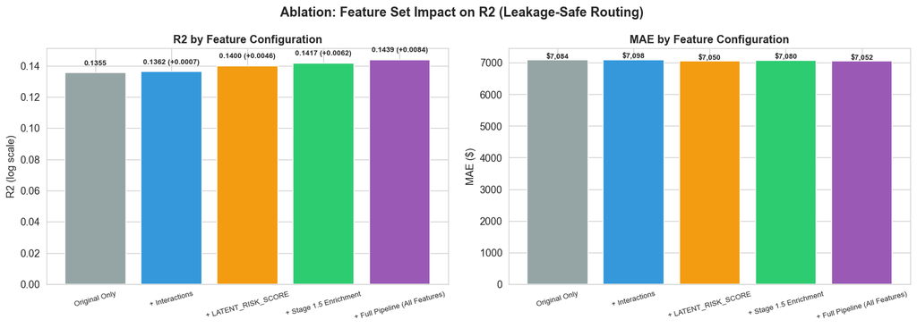

```python
# Ablation: Value of Latent Factors
print('ABLATION STUDY')

def train_tier_ablation(feat_list, name):
    feats = [f for f in feat_list if f in df.columns]

    # Global fallback model (always available)
    g_model = XGBRegressor(
        n_estimators=800,
        max_depth=6,
        learning_rate=0.03,
        subsample=0.8,
        colsample_bytree=0.8,
        reg_alpha=0.5,
        reg_lambda=3.0,
        random_state=42,
        n_jobs=-1,
        early_stopping_rounds=50,
    )
    g_model.fit(
        df_train[feats].fillna(0),
        y_train_log,
        eval_set=[(df_val[feats].fillna(0), y_val_log)],
        verbose=False,
    )
    g_train_pred = g_model.predict(df_train[feats].fillna(0))
    g_smear = np.mean(np.exp(y_train_log - g_train_pred))

    preds_log = g_model.predict(df_test[feats].fillna(0))
    preds_dollar = np.clip(np.expm1(preds_log) * g_smear, 0, None)

    # Tier overrides routed by Stage 1 predicted class
    for tv, tn in tier_names.items():
        tr_m = (df_train['RISK_TIER'].to_numpy() == tv)
        va_m = (df_val['RISK_TIER'].to_numpy() == tv)
        te_route_m = (stage1_pred_test == tv)

        if tr_m.sum() < 30 or va_m.sum() < 10:
            continue

        hp = tier_hyperparams.get(tv, tier_hyperparams[1])
        xg = XGBRegressor(
            n_estimators=hp['n_estimators'],
            max_depth=hp['max_depth'],
            learning_rate=0.03,
            subsample=0.8,
            colsample_bytree=0.8,
            reg_alpha=0.5,
            reg_lambda=hp['reg_lambda'],
            min_child_weight=hp['min_child_weight'],
            random_state=42,
            n_jobs=-1,
            early_stopping_rounds=50,
        )
        xg.fit(
            df_train.loc[tr_m, feats].fillna(0),
            np.log1p(y_train[tr_m]),
            eval_set=[(df_val.loc[va_m, feats].fillna(0), np.log1p(y_val[va_m]))],
            verbose=False,
        )

        tr_resid = np.log1p(y_train[tr_m]) - xg.predict(df_train.loc[tr_m, feats].fillna(0))
        smear = np.mean(np.exp(tr_resid))

        if te_route_m.sum() > 0:
            p_log = xg.predict(df_test.loc[te_route_m, feats].fillna(0))
            p_dollar = np.clip(np.expm1(p_log) * smear, 0, None)
            preds_log[te_route_m] = p_log
            preds_dollar[te_route_m] = p_dollar

    r2l = r2_score(y_test_log, preds_log)
    r2d = r2_score(y_test, preds_dollar)
    mae_v = mean_absolute_error(y_test, preds_dollar)
    print(f'  {name:35s}: R2_log={r2l:.4f}, R2_$={r2d:.4f}, MAE=${mae_v:,.0f}')
    return {'Model': name, 'R2_log': r2l, 'R2_dollar': r2d, 'MAE': mae_v, 'N_feats': len(feats)}

results = []
results.append(train_tier_ablation(original_avail, 'Original Only'))
results.append(train_tier_ablation(original_avail + interact_avail, '+ Interactions'))
results.append(train_tier_ablation(original_avail + interact_avail + ['LATENT_RISK_SCORE'], '+ LATENT_RISK_SCORE'))
results.append(train_tier_ablation(original_avail + interact_avail + stage1_5_avail, '+ Stage 1.5 Enrichment'))
results.append(train_tier_ablation(TIER_FEATS, '+ Full Pipeline (All Features)'))

abl_df = pd.DataFrame(results)
abl_df['R2_log_gain'] = abl_df['R2_log'] - abl_df['R2_log'].iloc[0]

fig, axes = plt.subplots(1, 2, figsize=(14, 5))
fig.suptitle('Ablation: Feature Set Impact on R2 (Leakage-Safe Routing)', fontsize=14, fontweight='bold')
colors = ['#95a5a6', '#3498db', '#f39c12', '#2ecc71', '#9b59b6']

ax1 = axes[0]
bars = ax1.bar(range(len(abl_df)), abl_df['R2_log'], color=colors[:len(abl_df)], edgecolor='white')
for b, v, g in zip(bars, abl_df['R2_log'], abl_df['R2_log_gain']):
    label = f'{v:.4f}' if g == 0 else f'{v:.4f} (+{g:.4f})'
    ax1.text(b.get_x() + b.get_width()/2, v + 0.005, label, ha='center', fontsize=8, fontweight='bold')
ax1.set_xticks(range(len(abl_df)))
ax1.set_xticklabels(abl_df['Model'], fontsize=8, rotation=15)
ax1.set_ylabel('R2 (log scale)', fontsize=11)
ax1.set_title('R2 by Feature Configuration', fontsize=12, fontweight='bold')

ax2 = axes[1]
bars = ax2.bar(range(len(abl_df)), abl_df['MAE'], color=colors[:len(abl_df)], edgecolor='white')
for b, v in zip(bars, abl_df['MAE']):
    ax2.text(b.get_x() + b.get_width()/2, v + 50, f'${v:,.0f}', ha='center', fontsize=8, fontweight='bold')
ax2.set_xticks(range(len(abl_df)))
ax2.set_xticklabels(abl_df['Model'], fontsize=8, rotation=15)
ax2.set_ylabel('MAE ($)', fontsize=11)
ax2.set_title('MAE by Feature Configuration', fontsize=12, fontweight='bold')

plt.tight_layout()
plt.savefig(REPORT_DIR / 'figures' / 'stage2_ablation.png', dpi=150, bbox_inches='tight')
plt.show()
abl_df.to_csv(REPORT_DIR / 'tables' / 'stage2_model_comparison.csv', index=False)
```

```python
# Save Output using selected Stage 2 strategy
print('Saving...')

# Full-data global prediction (fallback anchor)
full_global_log = global_xgb.predict(df[ALL_FEATS].fillna(0))
full_global_dollar = np.clip(np.expm1(full_global_log) * global_smearing, 0, None)

# Full-data Stage 1 fields
full_prob = df[stage1_prob_cols].to_numpy()
full_hard = df['pred_class_hard'].astype(int).to_numpy()
full_policy = df['pred_class_policy'].astype(int).to_numpy()
full_review = df['review_flag'].astype(int).to_numpy()
full_unc = df['uncertainty_score'].to_numpy()

# Precompute class expert predictions on full data
n_full = len(df)
full_class_pred = np.tile(full_global_dollar.reshape(-1, 1), (1, len(class_order)))
X_full_tier = df[TIER_FEATS].fillna(0)

for tier_val, tier_name in tier_names.items():
    if tier_name not in tier_models:
        continue
    mdl = tier_models[tier_name]['model']
    smear = smearing_factors.get(tier_name, 1.0)
    pred_all = np.clip(np.expm1(mdl.predict(X_full_tier)) * smear, 0, None)
    full_class_pred[:, tier_val] = pred_all

# Strategy predictions on full data
pred_full = {}

# Global
pred_full['GlobalFallback'] = {
    'dollar': full_global_dollar,
    'route_label': np.array(['GlobalFallback'] * n_full, dtype=object),
    'fallback_flag': np.ones(n_full, dtype=int),
}

# Hard routing
hard_route = full_policy.copy()
hard_missing = hard_route < 0
hard_route[hard_missing] = full_hard[hard_missing]

hard_dollar = full_global_dollar.copy()
hard_route_label = np.array(['GlobalFallback'] * n_full, dtype=object)
hard_route_label[hard_missing] = 'PolicyReviewFallback'
hard_fallback_flag = hard_missing.astype(int)

for tier_val, tier_name in tier_names.items():
    if tier_name not in tier_models:
        continue
    m = (hard_route == tier_val) & (~hard_missing)
    if m.sum() == 0:
        continue
    hard_dollar[m] = full_class_pred[m, tier_val]
    hard_route_label[m] = tier_name
    hard_fallback_flag[m] = 0

pred_full['HardRouting'] = {
    'dollar': hard_dollar,
    'route_label': hard_route_label,
    'fallback_flag': hard_fallback_flag,
}

# Soft routing
soft_dollar = np.sum(full_prob * full_class_pred, axis=1)
pred_full['SoftRouting'] = {
    'dollar': soft_dollar,
    'route_label': np.array(['SoftBlend'] * n_full, dtype=object),
    'fallback_flag': np.zeros(n_full, dtype=int),
}

# Soft + fallback
unc_cut = np.quantile(full_unc, 0.90)
soft_fb_flag = ((full_review == 1) | (full_unc >= unc_cut)).astype(int)
soft_fb_dollar = soft_dollar.copy()
soft_fb_dollar[soft_fb_flag == 1] = full_global_dollar[soft_fb_flag == 1]
soft_fb_label = np.array(['SoftBlend'] * n_full, dtype=object)
soft_fb_label[soft_fb_flag == 1] = 'SoftFallback_Global'

pred_full['SoftRoutingWithFallback'] = {
    'dollar': soft_fb_dollar,
    'route_label': soft_fb_label,
    'fallback_flag': soft_fb_flag,
}

# Select strategy fixed from test-set comparison
chosen = pred_full[best_strategy_name]
df['PREDICTED_COST_Y2'] = chosen['dollar']
df['STAGE2_STRATEGY'] = best_strategy_name
df['STAGE2_ROUTE_CLASS'] = chosen['route_label']
df['STAGE2_FALLBACK_FLAG'] = chosen['fallback_flag']

output_path = REPO_ROOT / 'data' / 'processed_v2' / 'model_ready_stage2.parquet'
output_path.parent.mkdir(parents=True, exist_ok=True)
df.to_parquet(output_path, index=False)
print(f'Saved to {output_path}: {len(df):,} rows, {len(df.columns)} cols')

print()
print('Selected strategy route distribution (full dataset):')
route_counts = pd.Series(chosen['route_label']).value_counts()
for k, v in route_counts.items():
    print(f'  {k:22s}: {v:>6,} ({v/len(df)*100:.1f}%)')
```

```
Saving...
```

```
Saved to /Users/duanduan/Documents/NEU/ALY6980/healthcare_repo/data/processed_v2/model_ready_stage2.parquet: 60,602 rows, 91 cols

Selected strategy route distribution (full dataset):
  Low_Stable            : 11,349 (18.7%)
  Low_Improve           : 10,905 (18.0%)
  High_Improve          :  7,554 (12.5%)
  Mid_Improve           :  6,377 (10.5%)
  Mid_Stable            :  6,224 (10.3%)
  Low_MildRise          :  5,665 (9.3%)
  High_Stable           :  4,172 (6.9%)
  High_Escalate         :  3,190 (5.3%)
  Mid_Escalate          :  2,964 (4.9%)
  Low_Jumper            :  2,202 (3.6%)
```

## Summary

**What Stage 2 establishes**

- Year 2 expenditure is too skewed to model well with a single undifferentiated story.
- Stage 1 provides routing structure.
- Stage 1.5 provides engineered predictors that capture care pattern, expected transition magnitude, and prescription continuity.
- The final comparison tells us whether probability-based routing is more robust than hard class assignment.

**What to report from this notebook**

1. Which routing strategy had the best held-out MAE.
2. Whether the gain came from class-specific experts, soft routing, or both.
3. Which engineered predictors repeatedly appeared near the top of expert models beyond `COST_Y1_ADJ`.

**What not to overclaim**

- A single engineered feature is not a clinical rule by itself.
- Some Stage 1.5 gains are incremental, not dramatic, and that is expected once strong baseline cost information is already present.
- The value of the pipeline is the combination of routing plus additional non-cost signal, not any one chart in isolation.